# Math_exp slides

## Mathematisches Experimentieren mit „ipython notebook“

### Forschendes Lernen in der Sek II

Dr. Martin Guggisberg  
Pädagogische Hochschule FHNW  
Basel, Schweiz

50. GDM-Jahrestagung Heidelberg 2016

## Gliederung

- Mathematisches Experimentieren mit elektronischen Laborjournale
- Exemplarisches Beispiel zum arithmetisch-musikalischem Gruppenspiel Ping-Pong

## Experimentieren

Durch Hypothesen geleitetes, **planvolles und kontrolliertes Handeln** mit Objekten zum Zweck der **Erkenntnisgewinnung** durch **Beobachtung**

( Ludwig & Oldenburg 2007)

### Experimentieren in der Mathematik

- Mathematik zum Anfassen (Mathematikum in Gießen, Beutelspacher)
- Lernen durch Experimentieren (Ludwig & Oldenburg)
- Mathematics by experiment (Borwein & Bailey)

### Mathematisches Experimentieren mit dem PC

A. Engel,Stuttgart : Klett, 1991 Inhalt: Zahlentheoretische Algorithmen, Wahrscheinlichkeit,Statistik, Kombinatorische Algorithmen

Mit dem Computer experimentieren $\to$ Wissenschaftliches Rechnen

Neue Studiengänge Computational Sciences in XXX

### Laborjournal

Systematische Aufzeichnung aller inneren und äusseren Paramter, geometrische Konfiguration, sowie die experimentel ermittelten Ergebnisse.

[figure not shown]

### Elektronische Laborjournale

- Automatisierte elektronische Erfassung aller Parameter
- Möglichkeit für interaktive, manuelle Ergänzungen (Figuren, math. Formeln, Texte) $$ \int_0^\infty x^2-x^3-x^4 dx$$
- Werkzeuge zur Datenvisualisierung

## Elektronische Laborjournale

### direktes Arbeiten in der Cloud

- https://try.jupyter.org/
- [https://studio.azureml.net/](https://try.jupyter.org/)

### nahtlose Verteilung

- Notebook Gallery http://nb.bianp.net/sort/views/
- Beispiele
  - [Functional Geometry](http://nbviewer.jupyter.org/github/shashi/ijulia-notebooks/blob/master/funcgeo/Functional%20Geometry.ipynb)
  - [Discrete Cosine Transform](http://nbviewer.jupyter.org/url/cs.marlboro.edu/courses/spring2014/information/code/dct/dct.ipynb)

### Voraussetzungen für mathematische Experimente

- Offen Ausgangslage
- Unüberschaubarer Konfigurationsraum
- Beispiele
  - Spiele wie z.B. Schach
  - Naturwissenschaftliche Simulationen
    - Aerodynamics-Hydrodynamics
    - [Reaktions-Diffusion-Systeme](https://github.com/mgje/Python-Mathematik-Beispiele/blob/master/Python-Notebooks/Reaktions-Diffusions-System.ipynb)
    - [Angetriebener harmonischer Oszillator](https://github.com/mgje/Python-Mathematik-Beispiele/blob/master/Python-Notebooks/Modellierung%20dynamischer%20Systeme.ipynb)
    - [Simulation von Schwarmverhalten](https://github.com/mgje/Python-Mathematik-Beispiele/blob/master/Python-Notebooks/Schwarm.ipynb)
    - [Statik Simulation](https://github.com/mgje/Python-Mathematik-Beispiele/blob/master/Python-Notebooks/Federmodell.ipynb)

### Einsatz von elektronischen Laborjournalen an der Hochschule

- Lehrerausbildung Masterkurs [Wissenschaftliches Rechnen](https://github.com/mgje/PIUMP/tree/master/Beispiele_Skript_SciComputing)
- EU Forschungsprojekt: ["European Music Portfolio - Maths: Sounding ways into Mathematics"](http://www.emportfolio.eu/)

## Ping-Pong Aktivität

[figure not shown]

Das Ping-Pong Spiel behandelt eine koordinative, kooperative, rhythmische AufgabensteIlung, welche mit Gruppen von 4 bis 26 Schülerinnen und Schülern durchgeführt werden kann.

[figure not shown]

Cslovjecsek, M., Guggisberg, M. & Linneweber-Lammerskitten H. (2011). Mathe macht Musik Ping-Pong, PM Praxis der Mathematik 42 (pp. 13 – 18).

### Spielregeln:

- Die ganze Klasse sitzt im Kreis.
- Dazu wird der Reihe nach fortlaufend gezählt (1,2, 3, 4 ...).
- In einem ersten Schritt werden alle Dreier-Zahlen (3, 6, 9, 12, 15 ...) mit dem Wort "Ping" ersetzt.
- Analog werden dann die Vierer-Zahlen (4, 8, 12, 16 .. .) mit ,,Pong" ersetzt.
- Nach einigem Üben kann versucht werden, die Dreier- und Vierer-Zahlen gleichzeitig zu ersetzen (12, 24 ... heißt dann Ping-Pong ).
- Viel Übung ist erforderlich, wenn bei Ping und Pong als zusätzliche Regel ein Richtungswechsel vorgenommen wird

### Spiel mit Ping = 3 und Pong = 4

[figure not shown]

### Was muss ich sagen, wenn ich an die Reihe komme ?

### Welche Zähl-Zahlen treten bei meiner Spielposition auf ?

### Gibt es eine Partitur für dieses Spiel ?

### Durch Abzählung zur Lösung

$\mathbb{N} \times \mathbb{N} \times \mathbb{N} \to \mathbb{Z}$

$(n, \mbox{Ping-Zahl}, \mbox{Pong-Zahl}) \mapsto \mbox{Spielposition}$

### Verschiedene Darstellungen des Spielverlaufs

### für ping = 3 und pong = 4

[figure not shown]

#### Durch Abzählen zur Lösung (Python Programm)

```python
def pingpong(n, ping=3, pong=4):
    p = 0
    # Zählschritt (1 oder -1)
    step = 1
    # Zählen von 1 bis n
    for i in range(1,n+1):
        p = p + step
        # Vergleiche Zähl-Zahl mit ping und pong
        # falls genau eine Bedingung zutrifft (xor)
        # -> ändere die Richtung (XOR)
        if bool(i%ping)^bool(i%pong):
            step *= (-1)
    return p

pingpong(4)
```

```
2
```

#### Pseudo-Code Ping-Pong zur Berechnung der Spielposition

```
p = 0
step = 1
for i : 1 .. N do
    p = p + step
    if (i mod ping) xor (i mod pong)
        step = (-1)* step
return p
```

## Spielpositionen für die ersten 30 Zähl-Zahlen

```python
y = [pingpong(n) for n in range(1,31)]
print y
```

```
[1, 2, 3, 2, 3, 4, 3, 2, 3, 2, 1, 0, -1, -2, -3, -2, -3, -4, -3, -2, -3, -2, -1, 0, 1, 2, 3, 2, 3, 4]
```

### Visualisierung des Spielverlaufs mithilfe eines Zähl-Zahl-Position-Diagramms

```
'Spielverlauf ping=3 , pong=4'
```

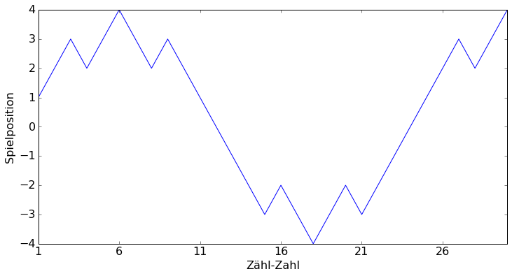

```python
init_plot()
xticks(np.arange(0,len(y),5),np.arange(1,len(y),5),size=16)
plot(y)
'Spielverlauf ping=3 , pong=4'
```

```
'Spielverlauf ping=3 , pong=5'
```

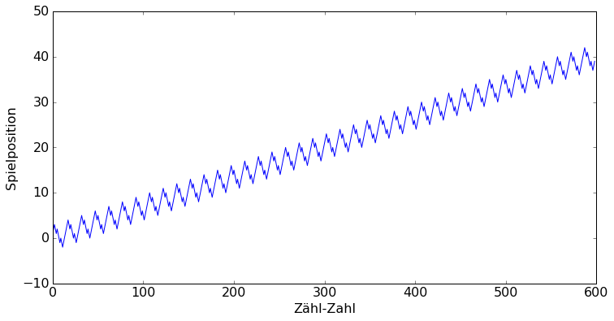

```python
## Abhängigkeit von Ping und Pong
ping = 3
pong = 5
y = [pingpong(n,ping,pong) for n in range(1,600)]
init_plot()
plot(y)
'Spielverlauf ping=%d , pong=%d' %(ping,pong)
```

### Weitere divergente Konfigurationen

```
'Spiele (ping=3,pong=5),(ping=3,pong=7),(ping=3,pong=9),(ping=3,pong=11)'
```

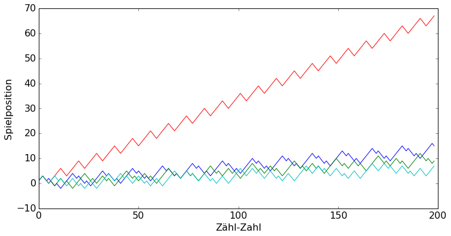

```python
y = [[pingpong(n,3,pong) for pong in range(5,12,2)] \
     for n in range(1,200) ]
init_plot()
plot(y)
#legend(('ping=3,pong=5','ping=3,pong=7','ping=3,pong=9','ping=3,pong=11'))
'Spiele (ping=3,pong=5),(ping=3,pong=7),(ping=3,pong=9),(ping=3,pong=11)'
```

```
'Spielverlauf ping=4 , pong=16'
```

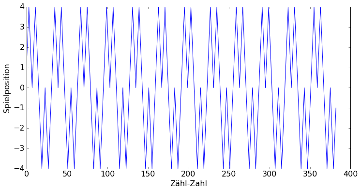

```python
ping=4
pong=16
init_plot()
y = [pingpong(n,ping,pong) for n in range(1,6*ping*pong)]
plot(y)
'Spielverlauf ping=%d , pong=%d' %(ping,pong)
```

### Ping-Pong Parameter Karte / Spielposition in Abhängigkeit von Ping und Pong

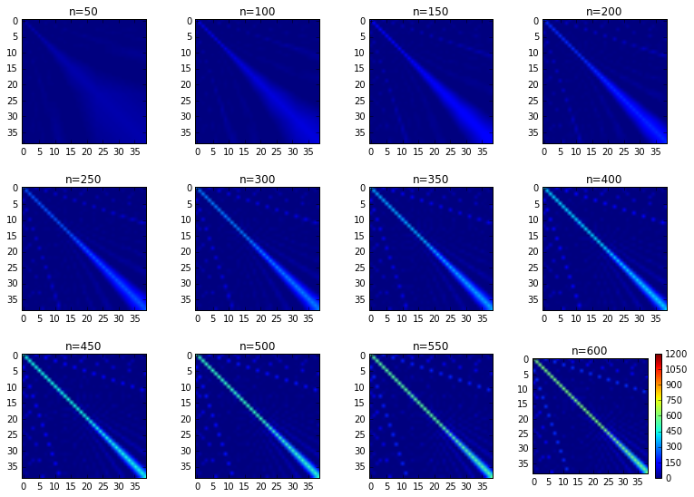

```python
plot_maps(0,1200)
```

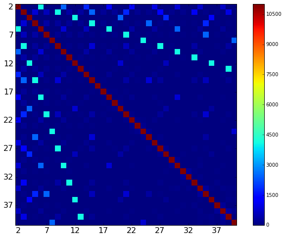

```python
plot_map_n_12347(0,11000)
```

divergente Fälle: (2,6);(3,9);(4,12);(5,15)  
(2,10);(3,15);(4,20)

## Wertebereiche auf -500 .. 500 einschränken

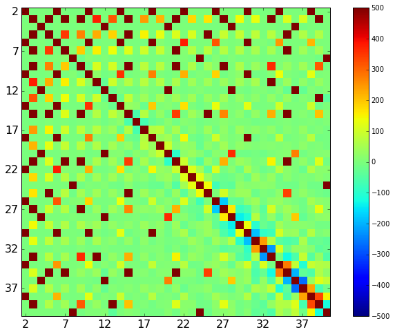

```python
plot_map_n_12347(-500,500)
```

### Betrachtung von Fälle ping > 35, pong > 36, nahe bei der Diagonalen

(39,40) , (39,38) , (39,36) (37,40) , (37,38) , (37,36) (35,40) , (37,38) , (37,36)

```
'Spielverlauf (35,36) , (35,38) , (35,40) , (37,36) , (37,38) , (37,40), (39,36) , (39,38) , (39,40)'
```

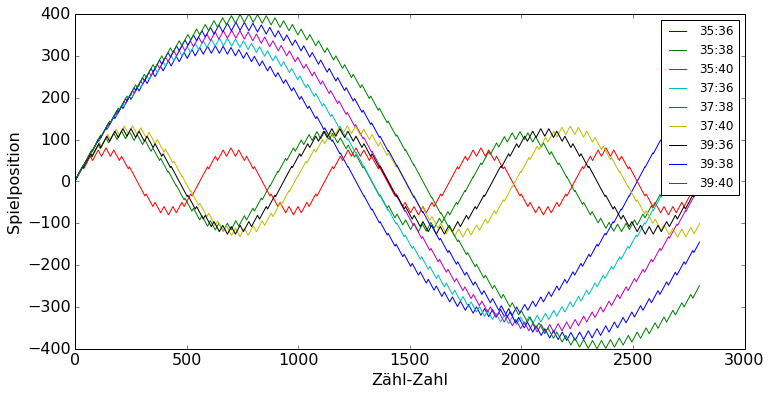

```python
init_plot()
legend((('p33:40', 'p35:40', 'p37:40', 'p39:40')))
y = [[pingpong(n,ping,pong) for ping in range(35,41,2) for pong in range(36,41,2)] for n in range(1,2800) ]
leg= [str(str(ping)+':'+str(pong)) for ping in range(35,41,2) for pong in range(36,41,2)]
plot(y)
legend(tuple(leg))
'Spielverlauf (35,36) , (35,38) , (35,40) , (37,36) , (37,38) , (37,40), (39,36) , (39,38) , (39,40)'
```

### Kombinationen von ungeraden und geraden teilerfremden Paare scheinen periodisch zu sein

Mit einer Periodizität von $2 \cdot ping \cdot pong $

Und einer Amplitude von $ \approx \frac{32}{125} \cdot ping \cdot pong $

```
'Spielverlauf ping=41 , pong=42'
```

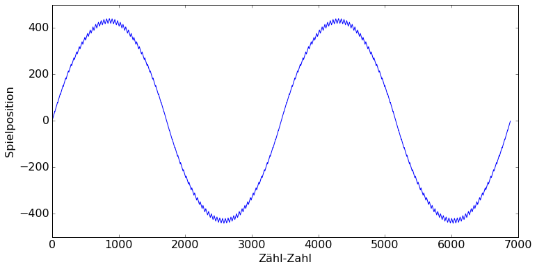

```python
ping = 41
pong = 42 #Torsten
init_plot()
y = [pingpong(n,ping,pong) for n in range(1,4*ping*pong) ]
plot(y)

'Spielverlauf ping=%d , pong=%d' %(ping,pong)
```

### Vergleich einer normalisierten Ping-Pong Kurve mit einer Sinus Funktion

```
'Approximation von sin(x) durch normalisierten Spielverlauf (41,42)'
```

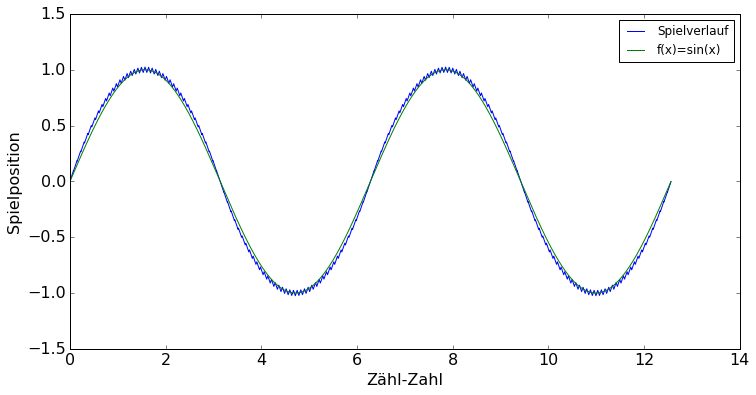

```python
x,y,y2 = fitPingPong(41,42)
init_plot()
plot(x,y,'-',x,y2,'-')
legend(('Spielverlauf','f(x)=sin(x)'))
'Approximation von sin(x) durch normalisierten Spielverlauf (41,42)'
```

### Potenzial von elektronischen Laborjournalen

- Abzählung von Möglichkeiten
- Numerischen Berechnungen
- Visualisierung von Phasenräumen
- interaktiv - direkt im Browser lauffähig
- Kann als Präsentationswerkzeug verwendet werden
- 100% Open Source

### Mögliche Themenfelder

- Numerik
- Mechanik
- Thermodynamik
- Populationsdynamik
- Informatik

`Mathematiker wie z.B. Fermat, Gauß, Euler oder Riemann haben viele Stunden ihres Lebens damit verbrachten, Rechnungen im Kopf durchzuführen, um „mögliche Wahrheiten“ zu erkunden.`

### Mögliche Themen für Schuluntericht (Sekundarstufe II):

- Entdecken durch Abzählen
  - Konvergenz von Folgen und Reihen
  - Berechnung von Wahrscheinlichkeiten
  - Approximation spezieller Zahlen
- Entdeckung durch Visualisierung
  - Verhalten von Funktionen
  - Symmetrien in der Ebene
- Experimentelle Untersuchung von Daten
  - Suche nach Gesetzmässigkeiten (Regression, Methode der kleinsten Quadrate)
  - Untersuchung von Korrelationen

# Vielen Dank !

### Alle Materialien sind auf github

### Dieses elektronische Laborjournal finden Sie auf

https://github.com/mgje/PIUMP

### Vortrag: Sounding Ways into Mathematics

#### Do 10.3. 8:15-9:00 Uhr Ort: A125

Musikalische Zugänge zur Mathematik – Sounding Ways into Mathematics

Andreas Richard, Markus Cslovjecsek